# calibration

### Calibration

This is the code for calibrating my model in Growth and Welfare Consequences of Sector Specific Innovations.

To calibrate my model, I target the United States non-financial corporate sector from 1987 to 2017 subject to availability of data.

```python
from IPython.display import Markdown as md
```

```python
# import all the packages I need to conduct the calibration.
import pandas as pd
import numpy as np
import matplotlib.pyplot as plt
import scipy.optimize as opt
from scipy.stats import pareto
import seaborn as sns
import pandas_datareader.data as web
import datetime
%matplotlib inline
darkmode = False
if darkmode:
    plt.style.use(['dark_background'])
else:
    plt.style.use(['ggplot'])
```

#### Growth rate of output, $g_y$

I target growth rate of real value added of non-financial corporate sector less indirect taxes less intellectual property products investments per worker for $g_y$.

I download data from St. Louis Fed FRED database.

```python
corporate = True
non_financial = True
```

```python
# calibration period, both integer and as datetime
init_year = 1987
last_year = 2017
start = datetime.datetime(init_year, 1, 1)
end = datetime.datetime(last_year, 12, 31)


# https://apps.bea.gov/iTable/iTable.cfm?reqid=19&step=2#reqid=19&step=2&isuri=1&1921=survey , GVA
# Table 1.14 Line 41
# B455RX1Q027SBEA, Real Gross value added of nonfinancial corporate business
# A455RC1Q027SBEA, Gross value added of nonfinancial corporate business
# PRS88003013, Nonfinancial Corporations Sector: Employment
# NCBPISQ027S, Nonfinancial corporate business; taxes on production and imports less subsidies, payable, Flow
series = ['A455RC1Q027SBEA','B455RX1Q027SBEA','NCBPISQ027S', 'PRS88003013']
GVA = web.DataReader( series, 'fred', start, end)
GVA.columns = ['gva','real gva','indirect tax','emp']
GVA = GVA.resample('A').mean()


# LFWA64TTUSM647S, Working Age Population: Aged 15-64: All Persons for the United States
pop = web.DataReader('LFWA64TTUSM647S','fred',start,end)
pop = pop.resample('A').mean()
pop.columns = ['pop']


#Investment in Private Nonresidential Fixed Assets by Industry Group and Legal Form of Organization
ipp = pd.read_csv('asset-investment.csv',skiprows=4)
int_year_index = np.argmax(ipp.columns.values == str(init_year))
last_year_index = np.argmax(ipp.columns.values == str(last_year))+1
cols =ipp.columns.values[int_year_index:last_year_index]
ipp_corp = pd.DataFrame(index=GVA.index,data=ipp[ipp.Line==40.0][cols].values.transpose(),columns=['ipp'])

GVA['ipp'] = ipp_corp.ipp
GVA['pop'] = pop['pop']

# Calculate the growth rate of output per worker
# output is gross value added minus taxes on production and imports less subsidies
# less investment in intellectul property prouducts, all in non-financial corporate sector
g_y = ((GVA['gva']-GVA['indirect tax']/1000-GVA['ipp'])*GVA['real gva']/GVA['gva']/GVA['emp']).pct_change().mean()

md('Balanced Growth Path output growth rate I will target is $g_y={0:.3f}.$'.format(g_y))
```

Balanced Growth Path output growth rate I will target is $g_y=0.016.$

```python
g_y_pop = ((GVA['gva']-GVA['indirect tax']/1000-GVA['ipp'])*GVA['real gva']/GVA['gva']/GVA['pop']).pct_change().mean()
a = 'An alternative target is growth rate of output per capita, which is equal to {0:.3f}.'.format(g_y_pop)
b = " I don't use this target, because everyone in my model works."
md(a+b)
```

An alternative target is growth rate of output per capita, which is equal to 0.017. I don't use this target, because everyone in my model works.

As I stated above, I will target non-financial corporate sector in my calibration. However, an alternative target is non-farm business sector.

```python
# MPU4910022, Private Non-Farm Business Sector: Real Value-Added Output
# nfbs_va = web.DataReader(['MPU4910022'],'fred',start,end)
# nfbs_va.columns = ['VA']

# PRS85006013, Nonfarm Business Sector: Employment
# nfbs_emp = web.DataReader('PRS85006013','fred',start,end)
# nfbs_emp = nfbs_emp.resample('A',label='left').mean()
# nfbs_emp.columns = ['emp']
```

I target $R=.04$ as in Atkeson and Burstein (2018).

```python
R = .04
```

```python
rho = R-g_y
a = r'In equilibrium $R=g_C+\rho$, which makes $\rho=R-g_C={0:.3f}.$'.format(R-g_y)
md(a)
```

In equilibrium $R=g_C+\rho$, which makes $\rho=R-g_C=0.024.$

```python
download_data = False
if download_data:
    variables = pd.read_excel('./concord/bds_vars.xlsx')
    var_list=",".join(variables['variable'].values)

    ifsize = {'a':'1 to 4','b' :'5 to 9','c':'10 to 19','d':'20 to 49',
              'e':'50 to 99','f':'100 to 249','g':'250 to 499','h':'500 to 999',
              'i':'1000 to 2499','j':'2500 to 4999','k':'5000 to 9999','l':'10000+',
              'm': 'Economy Wide'}

    sic1_not = {'0':'EW','7':'AGR','10':'MIN','15':'CON','20':'MAN',
                '40':'TCU','50':'WHO','52':'RET','60':'FIRE','70':'SRV'}

    sic1 = {'00':'Economy Wide','07':'Agriculture, Forestry, and Fishing',
            '10':'Mining','15':'Construction','20':'Manufacturing',
            '40':'Transportation, Communication, and Public Utilities',
            '50':'Wholesale Trade','52':'Retail Trade',
            '60':'Finance, Insurance, and Real Estate','70':'Services'}

    fage4 ={'a':'0','b':'1','c':'3','d':'3','e':'4',
            'f':'5','g':'6-10','h':'11-15','i':'16-20',
            'j':'21-25','k':'26+','l':'Left Censored',
            'm':'Economy Wide'}

    labels = {'fsize':ifsize,'sic1':sic1_not,'fage4':fage4}

    key = '10d154bf4604fa02fd1fa80cd2e1b138dcfd7e99'
    url_base = 'https://api.census.gov/data/timeseries/bds/firms?get='
    url_time = '&for=us:00&time='
    url_key = '&key='+key

    url_down = url_base+var_list+url_time+'1977'+url_key
    bds = pd.read_json(url_down)
    columns = bds.iloc[0]
    bds.columns = columns
    bds = bds.drop(0)

    for year in range(1978,2015):
        url_down = url_base+var_list+url_time+str(year)+url_key
        data = pd.read_json(url_down)
        columns = data.iloc[0]
        data.columns = columns
        data = data.drop(0)
        bds = bds.append(data,ignore_index=True)

    bds = bds.drop('us',axis=1)
    bds = bds.astype({'time':int})
    bds['fsize'] = bds.fsize.map(ifsize)
    bds['sic1'] = bds.sic1.map(sic1_not)
    bds['fage4'] = bds.fage4.map(fage4)

    sic_names = {'EW': 'Economy wide', 'AGR': 'Agriculture', 'MIN': 'Mining',
                 'CON':'Construction', 'MAN':'Manufacturing',
                 'TCU':'Transportation and public utilities', 'WHO': 'Wholesale trade',
                 'RET':'Retail trade', 'FIRE':'Finance, insurance, and real estate',
                 'SRV':'Services'}

    bds['sic'] = bds.sic1.map(sic_names)

    def decades(row):
        if ((row>=1983) & (row<1993)):
            m = '1983-1993'
        elif ((row>=1993) & (row<2003)):
            m = '1993-2003'
        elif ((row>=2003) & (row<2013)):
            m = '2003-2013'
        elif (row>=2013):
            m = '2013+'
        elif (row<1983):
            m = '1983-'
        return m

    bds['decades'] = bds['time'].map(decades)

    entrant = [str(i) for i in np.arange(6)]
    bds['entrant'] =bds.fage4.map(lambda x: x in entrant)
    bds['all'] = bds.fage4.map(lambda x: x == 'Economy Wide')

    bds.to_csv('./data/bds_all.csv',index=False)
else:
    bds = pd.read_csv('./data/bds_all.csv')
```

### Generating concordence among SIC, NAICS, and I-O industries

1. Using [Distribution of Employment from SIC Divisions to NAICS Supersectors (in thousands)](https://www.bls.gov/ces/cesnaics02.htm#ratAGENDA-INSERTION-POINT), link SIC divisions in BDS data to NAICS supersectors. Notice that this shares data was created using 2001 data.
2. Using [Current Employment Statistics (Establishment Survey)](https://fred.stlouisfed.org/categories/11) data, link NAICS supersectors to NAICS 2-Digit industries.
3. Using BEA I-O and NAICS crosswalk, link 2-Digit NAICS industries to I-O data.

```python
# SIC Divisions to NAICS Supersectors link is a web table, and I copy pasted it to an excel file.
# A better approach definitely exist, but for the time being, this approach also works.
sic_naics = pd.read_excel('./concord/sic-naics.xlsx')
# in the copy paste process, subnotes show as negative numbers, hence I clean them by replacing negatives with zeros.
sic_naics = sic_naics.applymap(lambda x: x if x>= 0 else 0)
# keep only the percents, levels are not needed.
sic_naics_shares = sic_naics.xs('Percent',level=1)
# convert wide table to long table
sic_naics_shares = sic_naics_shares.reset_index().rename(columns={'index':'naics super'})
cols = sic_naics_shares.columns.values[1:]
sic_naics_shares=pd.melt(sic_naics_shares,id_vars=['naics super'],value_vars=cols,var_name='sic',value_name='share')
```

```python
# for example, Manufacturing NAICS supersector have 98.2% employment in Manufacturing SIC,
# .2% Wholesale trade SIC, .9% Retail trade SIC, and .8% Services SIC.
# Shares don't necessarily add up to 100%.
sic_naics_shares[sic_naics_shares['naics super']=='Manufacturing']
```

|  | naics super | sic | share |
| --- | --- | --- | --- |
| 2 | Manufacturing | Mining | 0.0 |
| 12 | Manufacturing | Construction | 0.0 |
| 22 | Manufacturing | Manufacturing | 98.2 |
| 32 | Manufacturing | Transportation and public utilities | 0.0 |
| 42 | Manufacturing | Wholesale trade | 0.2 |
| 52 | Manufacturing | Retail trade | 0.9 |
| 62 | Manufacturing | Finance, insurance, and real estate | 0.0 |
| 72 | Manufacturing | Services | 0.8 |

```python
# Now find shares of 2-Digit NAICS industries in NAICS supersectors.
# Here are the NAICS supersectors:
sic_naics_shares['naics super'].unique()
```

```
array(['Mining and logging', 'Construction', 'Manufacturing',
       'Trade, transportation, and utilities', 'Information',
       'Financial activities', 'Professional and business services',
       'Education and health services', 'Leisure and hospitality',
       'Other services'], dtype=object)
```

[Here are the subsectors of NAICS supersectors](https://www.bls.gov/sae/saesuper.htm)

```python
NAICS_super_2_digit = {'Mining and logging': ['Logging','Mining'],
                       'Construction':'Construction',
                       'Manufacturing':'Manufacturing',
                       'Trade, Transportation, and Utilities':['Wholesale Trade','Retail Trade',
                                        'Transportation and Warehousing','Utilities'],
                       'Information':'Information',
                       'Financial Activities':['Finance and Insurance Sector','Real Estate and Rental and Leasing'],
                       'Professional and Business Services':['Professional, Scientific, and Technical Services Sector',
                                     'Management of Companies and Enterprises Sector',
                                      'Administrative and Support and Waste Management and Remediation Services'],
                      'Education and Health Services':['Educational Services Sector',
                                                       'Health Care and Social Assistance'],
                      'Leisure and Hospitality':['Arts, Entertainment, and Recreation Sector',
                                                 'Accommodation and Food Services'],
                      'Other Services':'ther Services, except Public Administration',
                      'Government':['Federal Government','State Government','Local Government']}

naics_2_digit_super = {'Education and health services':'Education and health services' ,
            'Leisure and hospitality': 'Leisure and hospitality',
            'Mining and logging':'Mining and logging',
            'Utilities' : 'Trade, transportation, and utilities',
            'Construction' :  'Construction',
            'Wholesale Trade': 'Trade, transportation, and utilities',
            'Information':'Information',
            'Other services, except Public Administration':'Other services',
            'Other services':'Other services',
            'Manufacturing':'Manufacturing',
            'Retail Trade': 'Trade, transportation, and utilities',
            'Transportation and Warehousing':'Trade, transportation, and utilities',
            'Trade, transportation, and utilities':'Trade, transportation, and utilities',
            'Financial activities':'Financial activities',
            'Professional and business services':'Professional and business services',
            'Government':'Government'}

# 2-digit-IO
# 6           [62, 61] : Education and Health Services
# 7           [72, 71] :  Leisure and Hospitality
# 11              [11] : ?? Agriculture ?
# 21              [21] : Mining and Logging
# 22              [22] : Utilities
# 23              [23] : Construction
# 42              [42] : Wholesale Trade
# 51              [51] : Information
# 81              [81] : Other Services, except Public Administration
# 31G     [32, 31, 33] : Manufacturing
# 44RT        [45, 44] : Retail Trade
# 48TW        [49, 48] : Transportation and Warehousing
# FIRE        [52, 53] : Financial Activities
# G               [49] : ?? Government with Transportation and Warehousing
# PROF    [56, 54, 55] : Professional and Business Services
```

```python
# Download employment data for NAICS 2-digit sectors from FRED
# As the SIC - NAICS shares are based on 2001 Q1 data, download 2001 Q1 Employment
start = datetime.datetime(2001, 1, 1)
end = datetime.datetime(2001, 3, 31)
emp_series = ['USMINE','USCONS','MANEMP','USTPU','USWTRADE','USTRADE','CES4300000001',
              'CES4422000001','USINFO','USFIRE','USPBS','USEHS','USLAH','USSERV','USGOVT'] #,'DMANEMP','NDMANEMP',
data = web.DataReader( emp_series, 'fred', start, end)
# Convert monthly data to quarterly by taking mean
data = data.resample('Q').mean()

emp_series_dict = {'USMINE':'Mining and logging','USCONS':'Construction','MANEMP':'Manufacturing',
                   'USTPU':'Trade, transportation, and utilities','USWTRADE':'Wholesale Trade',
                   'USTRADE':'Retail Trade','CES4300000001':'Transportation and Warehousing',
                   'CES4422000001':'Utilities','USINFO':'Information',
                   'USFIRE':'Financial activities','USPBS':'Professional and business services',
                   'USEHS':'Education and health services','USLAH':'Leisure and hospitality',
                   'USSERV':'Other services','USGOVT':'Government'}

# rename columns to describe NAICS industries
data = data.rename(columns=emp_series_dict)

# convert wide table into long table
data = data.melt(var_name='naics',value_name='emp')

# create a crosswalk from naics 2 digit to supersectors
data['naics super'] = data.naics.map(naics_2_digit_super)
# calculate employment share of 2 digit industries on supersectors
g = lambda x: data[data.naics==x]['emp'].values[0]
naics_super_emp = data['naics super'].map(g)
data['naics super emp'] = naics_super_emp
data['emp share'] = data['emp']/data['naics super emp']

# merge sic_naics shares with employment shares data
sic_naics_shares = sic_naics_shares.merge(data,on='naics super',how='left')

# rename columns and drop no longer necessary columns
sic_naics_share = sic_naics_shares.rename(columns={'share':'sic share', 'emp share': 'naics share'}).drop(
    ['emp','naics super emp'],axis=1)

# share columns is the share of 2-digit naics industry employment coming from SIC divisions
sic_naics_share['share'] = sic_naics_share['sic share']/100*sic_naics_share['naics share']
naics_sic_share  = sic_naics_share.groupby(['sic','naics'])['share'].sum().reset_index()

# shares of 2-digit industries that are not superindustries does not add up to 1,
# as 2-digit industry is a sub industry
naics_sic_share.groupby('naics').sum()
```

| naics | share |
| --- | --- |
| Construction | 1.000000 |
| Education and health services | 1.000000 |
| Financial activities | 1.000000 |
| Information | 0.999000 |
| Leisure and hospitality | 1.000000 |
| Manufacturing | 1.001000 |
| Mining and logging | 1.000000 |
| Other services | 0.999000 |
| Professional and business services | 1.000000 |
| Retail Trade | 0.585389 |
| Trade, transportation, and utilities | 1.000000 |
| Transportation and Warehousing | 0.169152 |
| Utilities | 0.022855 |
| Wholesale Trade | 0.222596 |

### Now link I-0 industries to SIC-NAICS crosswalk

```python
# Convert poorly written (for machines) IO-Naics concordence
# into a matrix form.
io_naics = pd.read_excel('./concord/io_naics_raw.xlsx')
# drop unnecessary entries
io_naics = io_naics.drop('notes',axis=1)
io_naics = io_naics.dropna(how='all')
io_index = io_naics.index.values
# add 2-digit-IO codes to multi-digit ones
for i in range(len(io_index)):
    if pd.isna(io_naics.loc[io_index[i]]['2-digit-IO']):
        io_naics.loc[io_index[i]]['2-digit-IO'] = io_naics.loc[io_index[i-1]]['2-digit-IO']

# add 2-digit-names to missing entries
io_naics_index = io_naics.index.values
m = [io_naics.loc[io_naics_index[0]]['2-digit-name']]
for i in range(1,len(io_naics_index)):
    if io_naics.loc[io_naics_index[i]]['2-digit-IO'] == io_naics.loc[io_naics_index[i-1]]['2-digit-IO']:
        m.append(m[i-1])
    else:
        m.append(io_naics.loc[io_naics_index[i]]['2-digit-name'])
io_naics['2-digit-name']=pd.DataFrame(index=io_naics_index,data=m)
# I don't need to multi-digit names
io_naics = io_naics.dropna(subset=['Mult-digit-name','naics'])

# corresponding naics codes IO industries are not listed one by one,
# instead they were specified with ","s and '-'s: e.g. 11113-6, 11119
# this function, takes each entry with the above form and converts into list: [11113,11114,11115,11116,11119]
def naics_list(naics):
    naics_list = []
    if isinstance(naics, int):
        naics_list += [str(naics)]
    else:
        naics_ = naics.split(',')
        for naics__ in naics_:
            k = naics__.split('-')
            if len(k)==1:
                naics_list += k
            else:
                k0 = k[0][-1]
                k1 = k[1]
                k2 = k[0]
                klist = np.arange(int(k2),int(k2)+int(k1)-int(k0)+1)
                naics_list +=list(np.array(klist,dtype=str))
    return naics_list

io_naics['naics_list'] = io_naics['naics'].map(naics_list)

# take the multi digit NAICS codes and assign 2-digit-values
def naics_2_digit(group):
    m =list(group.naics_list.values)
    flat_list = [item for sublist in m for item in sublist]
    c_3 = set()
    for c_ in flat_list:
        c__ = c_.strip()
        c_3.add(c__[:2])
    return list(c_3)

# for each 2-digit-IO, find the 2-digit Naics it corresponds to
IO_naics_2_digit = io_naics.groupby('2-digit-IO').apply(naics_2_digit)
# rename columns
IO_naics_2_digit = IO_naics_2_digit.reset_index().rename(columns={'2-digit-IO':'IOCode',0:'Naics code'})
IO_naics_2_digit['IOCode'] = IO_naics_2_digit['IOCode'].astype('str')

# create a new columns of NAICS industry names
io_naics_dict = {'6':'Education and health services',
                '7': 'Leisure and hospitality',
                '11':'Agriculture','21':'Mining and logging',
                '22': 'Utilities','23':'Construction', '42':'Wholesale Trade',
                '51':'Information','81':'Other services',
                '31G':'Manufacturing','44RT':'Retail Trade',
                '48TW':'Transportation and Warehousing',
                'FIRE':'Financial activities','G':'Government',
                'PROF':'Professional and business services'}


io_naics_2_digit_names = IO_naics_2_digit['IOCode'].map(io_naics_dict)
IO_naics_2_digit['naics'] = io_naics_2_digit_names

# IO-NAICS 2 digit correspondence in long-form, each IO-Naics pair a new row
def expand(group):
    naics_man = group['Naics code']
    io_man = [group['IOCode'],]*len(naics_man)
    return pd.DataFrame({'IOCode':io_man,'naics':naics_man})

m = expand(IO_naics_2_digit.loc[IO_naics_2_digit.index[0]])
for i in IO_naics_2_digit.index:
    m = m.append(expand(IO_naics_2_digit.loc[IO_naics_2_digit.index[i]]))
IO_naics_2_digit_long = m
IO_naics_2_digit_long.rename(columns={'naics':'naics code'},inplace=True)

# merge NAICS-SIC crosswalk with IO-NAICS crosswalk
naics_sic_io = naics_sic_share.merge(IO_naics_2_digit,on='naics',how='inner')
```

```python
# merge BDS (Economy Wide) to NAICS-IO-SIC crosswalk using SIC
select_on = ((bds.fage4=='Economy Wide') & (bds.ifsize=='m') & (bds.fsize=='Economy Wide'))
bds_try = bds[select_on].merge(naics_sic_io,on='sic',how='left')

cols = ['emp', 'estabs', 'estabs_entry','estabs_exit',
       'firmdeath_emp', 'firmdeath_estabs',
       'firmdeath_firms', 'firms', 'job_creation',
       'job_creation_births', 'job_creation_continuers',
        'job_destruction',
       'job_destruction_continuer', 'job_destruction_deaths']

# BDS uses SIS as industry classification. This step converts it NAICS/IO by
# multiplying share of NAICS employment coming from SIC employment in 2013,
# and summing over IO-NAICS-time pairs. i.e, NAICS statistics are employment weighted
# averages of SIC statistics.
bds_try[cols] = bds_try[cols].astype(np.float).multiply(bds_try.share,axis=0)
bds_naics = bds_try.groupby(['IOCode','naics','time'])[cols].sum(axis=0).reset_index()
```

### I-O data

```python
# Download I-O data or load from pre-downloaded file
download_IO = False
get_table_ID = False
if download_IO:
    user_id =  '7747DFCB-B1D9-48B7-B86F-DE0D7F60ADF6'
    # get table id
    table_id_script='&method=GetParameterValues&DataSetName=InputOutput&ParameterName=TableID&ResultFormat=json'
    if get_table_ID:
        path = 'https://apps.bea.gov/api/data/?&UserID='+user_id+table_id_script
        table_ids = pd.read_json(path)
        table_ids.iloc[1]['BEAAPI']

    get_table_script = '&method=GetData&DataSetName=InputOutput&Year=ALL&tableID=47&&ResultFormat=json'
    path = 'https://apps.bea.gov/api/data/?&UserID='+user_id+get_table_script
    data = pd.read_json(path)
    io = pd.DataFrame(data.iloc[1]['BEAAPI']['Data'])
    io.to_csv('./data/io.csv')
else:
    io = pd.read_csv('./data/io.csv',index_col=0)
```

```python
# select industries on BDS data
industries = bds_try.IOCode.unique()[1:]
select = io.RowCode.map(lambda x: x in industries)

# select also 'F010' (Personal consumption expenditures)
#             'F020' (Private fixed investment)
#             'F030' (Change in private inventories)
industries_extended = list(industries)+['F010','F020','F030']
select_col = io.ColCode.map(lambda x: x in industries_extended)
```

Following function calculates consumption share of each industries output while taking intermediate inputs into account. Methodology is from Sector-Specific Technological Change by Basu, Feranld, Fisher, and Kimball (2013).

Consumption share of each industry is $\phi = (I-B)^{-1}\psi$, where **B** is the I-O matrix, and $B_{i,j}$ is share of commodity *i* output used in industry *j* production. $\psi$ is the share of commodity $i$ output consumed by households.

```python
def cons_inv_int_share(group):
    # create matrix
    single_year = group.pivot(index='RowCode',columns='ColCode',values='DataValue').fillna(0)
    # convert I-O matrix into shares with each row sums to 1 across columns.
    single_year_shares = single_year.div(single_year.sum(axis=1),axis=0)
    # make sure that row and columns industries are ordered the same
    m=list(single_year_shares.index.values)
    n= m+list(np.setdiff1d(single_year_shares.columns,m))
    single_year_share = single_year_shares[n]
    # formula of this described above
    cons_share = (np.linalg.inv(np.identity(len(single_year_share))
                                -single_year_share[m].values).dot(single_year_share['F010'].values))
    # investment share is 1 - consumption share
    inv_share = 1-cons_share
    # create a dataframe to return
    result = pd.DataFrame(index=m,data={'Consumption Share':cons_share,'Investment Share':inv_share})
    result.index.name = 'IOCode'
    return result

# calculate consumtion shares for each year
cons_inv_share = io[select & select_col].groupby('Year').apply(cons_inv_int_share).reset_index()

# take average over time
cons_inv_share_mean = cons_inv_share.groupby('IOCode')[['Consumption Share','Investment Share']].mean().reset_index()

# merge IO data into BDS data using IO codes
bds_io = bds_naics.merge(cons_inv_share_mean,on='IOCode',how='left')
```

### Industry Economic Accounts Data: GDP by Industry

These data are needed to calibrate labor share of income in each industry. The first data contains only compensation of employees but not labor compensation. Hence, I'll infer labor compensation as

- compensation of employees * (number of persons engaged) / (number of employees)

```python
# Even though I don't need the data here, (as I later import it),
# API data comes with industry codes, which are handy in merging datasets

# Create an extra column for the compensation type
def classify_rows(row):
    if row == 'Compensation of employees':
        x= 1
    elif row == 'Taxes on production and imports less subsidies':
        x = 2
    elif row == 'Gross operating surplus':
        x = 3
    else:
        x = 0
    return x


income_short = True
if income_short:
    user_id =  '7747DFCB-B1D9-48B7-B86F-DE0D7F60ADF6'
    # get table id
    table_path = '&method=GetParameterValues&DataSetName=GDPByIndustry&ParameterName=TableID&ResultFormat=json'
    #path = 'https://apps.bea.gov/api/data/?&UserID='+user_id+table_path
    #table_ids = pd.read_json(path)

    data_path='&method=GetData&DataSetName=GDPByIndustry&Year=ALL&Industry=ALL&tableID=6&Frequency=A&ResultFormat=json'
    path = 'https://apps.bea.gov/api/data/?&UserID='+user_id+data_path
    data = pd.read_json(path)
    income = pd.DataFrame(data.iloc[1]['BEAAPI']['Data'])
    income['component'] = income.IndustrYDescription.apply(classify_rows)
    industries = income[(income.component==0)][['Industry','IndustrYDescription']].drop_duplicates()
    income = income.drop(income[income.component==0].index)
    income = income.rename(columns={'IndustrYDescription':'Component'}).merge(industries,on='Industry')
    income['DataValue'] = income['DataValue'].astype(float)
```

```python
income_long = pd.read_excel('./data/gdp_by_industry.xlsx')
income_long_cols = income_long.columns[2:]
# industry column (which is not exactly industry) covered with white space
# remove white space
income_long['industry'] = income_long['industry'].str.strip()
# classify 'industry' into (actual) industry, compensation of employees, taxes, profits
income_long['component'] = income_long.industry.apply(classify_rows)
income_long_index = income_long.index.values
m = [income_long.loc[income_long_index[0]].industry]
# here I create a list, if I come across an actual industry, I assign the industry to the list,
# if not, I assign the previous industry to the list.
for i in range(1,len(income_long_index)):
    if income_long.loc[income_long_index[i]].component == 0:
        m.append(income_long.loc[income_long_index[i]].industry)
    else:
        m.append(m[i-1])
income_long['industry wide'] = pd.DataFrame(index=income_long_index,data= m).rename(columns={0:'industry wide'})
# convert wide format data into long format
income_long = income_long.melt(id_vars=['industry wide','industry', 'component'],
                               value_vars=income_long_cols,var_name='time',value_name='Value')
# merge with industries (industry name and code I downloaded above)
income_long = income_long.merge(income[['Industry','IndustrYDescription']].drop_duplicates().rename(columns={
        'IndustrYDescription': 'industry wide','Industry':'IOCode'}),on='industry wide', how='left')
income_long = income_long[income_long.IOCode.map(lambda x: x in bds_io.IOCode.unique())]

# still the industry column contains both industry name (which represents gross value added)
# and components of value added. Replace industry names with 'value added'
def change_ind_name(x):
    cols = ['Compensation of employees',
           'Taxes on production and imports less subsidies',
           'Gross operating surplus']
    if x in cols:
        return x
    else:
        return 'Value added'

income_long['industry']=income_long.industry.map(change_ind_name)

# reshape the data such data value added components are in columns
def pivot_income(group):
    group = group.pivot(index='IOCode',columns='industry',values='Value').reset_index()
    group = group[group.columns[1:]]
    group.columns.name = ''
    return group

income_flat = income_long.groupby(['IOCode','time']).apply(pivot_income).reset_index().drop('level_2',axis=1)

# save time (year) as integer
income_flat['time'] = income_flat.time.astype(int)
```

```python
# merge bds_io and income data
bds_io_income = bds_io.merge(income_flat,on=['IOCode','time'],how='left')
```

This is the data on number of persons engaged and full time equivalent number of employees

```python
# import the number of persons engaged data (1998-)
persons_engaged_1998_ = pd.read_csv('./data/persons_engage_1998_.csv',skiprows=4)
persons_engaged_1998_ =persons_engaged_1998_.loc[1:97].drop('Line',axis=1).rename(columns={'Unnamed: 1':'naics'})
# naics industries in the csv file contains footnotes, clear those
persons_engaged_1998_['naics']=persons_engaged_1998_['naics'].map(lambda x: ''.join([i for i in x if not i.isdigit()]))
# convert wide form data to long form data
persons_engaged_1998_ = persons_engaged_1998_.melt(id_vars='naics',value_vars=persons_engaged_1998_.columns[1:],
                                                   var_name='time',value_name='persons_engaged')

# import the number of full time equivalent employees data (1998-)
full_time_1998_ = pd.read_csv('./data/full_time_1998_.csv',skiprows=4)
full_time_1998_ = full_time_1998_.loc[1:97].drop('Line',axis=1).rename(columns={'Unnamed: 1':'naics'})
# naics industries in the csv file contains footnotes, clear those
full_time_1998_['naics'] = full_time_1998_['naics'].map(lambda x: ''.join([i for i in x if not i.isdigit()]))
# convert wide form data to long form data
full_time_1998_ = full_time_1998_.melt(id_vars='naics',value_vars=full_time_1998_.columns[1:],
                                       var_name='time',value_name='full_time')

# merge number of persons engaged and full time equivalent data
employment = persons_engaged_1998_.merge(full_time_1998_,on=['naics','time'])
# clear whitespaces in naics column
employment['naics']=employment.naics.str.strip()
# assign proper datatypes
employment = employment.astype(dict(zip(employment.columns[1:],[int,float,float])))
# this is the data that have both industry names and codes for the BEA industries
industries = industries.rename(columns={'IndustrYDescription':'naics'})
employment = employment.merge(industries,on='naics',how='left')
employment = employment.rename(columns={'Industry':'naics code'})

# keep only 2-digit IO industries
employment_short = (employment.merge(IO_naics_2_digit_long, on='naics code', how='right')
                    .groupby(['IOCode','time'])[['full_time','persons_engaged']].sum().reset_index())
```

```python
# download persons engaged and full time equivalent employment data from 1987 to 2000
# industry classification is SIC now
persons_engaged_1987_2000 = pd.read_csv('./data/persons_engaged_1987_2000.csv',skiprows=4)
persons_engaged_1987_2000=persons_engaged_1987_2000.loc[1:87].drop('Line',axis=1).rename(columns={'Unnamed: 1':'sic'})
persons_engaged_1987_2000['sic']=persons_engaged_1987_2000['sic'].str.strip()
persons_engaged_1987_2000['sic']=persons_engaged_1987_2000['sic'].map(lambda x: ''.join(
        [i for i in x if not i.isdigit()]))
persons_engaged_1987_2000 = persons_engaged_1987_2000.melt(id_vars='sic',
                    value_vars=persons_engaged_1987_2000.columns[1:],var_name='time',value_name='persons_engaged')

full_time_1987_2000 = pd.read_csv('./data/full_time_1987_2000-SIC.csv',skiprows=4)
full_time_1987_2000 = full_time_1987_2000.loc[1:87].drop('Line',axis=1).rename(columns={'Unnamed: 1':'sic'})
full_time_1987_2000['sic']=full_time_1987_2000['sic'].str.strip()
full_time_1987_2000['sic'] = full_time_1987_2000['sic'].map(lambda x: ''.join([i for i in x if not i.isdigit()]))
full_time_1987_2000 = full_time_1987_2000.melt(id_vars='sic',value_vars=full_time_1987_2000.columns[1:],
                                    var_name='time',value_name='full_time')

employment_1987_2000 = persons_engaged_1987_2000.merge(full_time_1987_2000,on=['sic','time'])
employment_1987_2000 = employment_1987_2000.astype(dict(zip(employment_1987_2000.columns[1:],[int,float,float])))
```

```python
# check that all the sic industries in the BDS data set are contained in this
# employment data covering 1987 to 2000
for ind in sic_naics_share.sic.unique():
    if ind not in employment_1987_2000.sic.unique():
        print(ind)
```

```python
# convert sic industries to IO/naics
employment_old_long= sic_naics_share.merge(employment_1987_2000,on='sic',how='left')

employment_old_long[['persons_engaged','full_time']] =( employment_old_long[['persons_engaged','full_time']].
                                                       multiply(employment_old_long['share'],axis=0))

employment_old_short = (employment_old_long.groupby(['naics','time'])[['persons_engaged','full_time']]
                        .sum(axis=1).reset_index())

employment_old_short = employment_old_short.merge(IO_naics_2_digit,on='naics',how='right').drop('Naics code',axis=1)
```

```python
# combine data from 1987 to 1998 with data from 1998 to
employment_combined = employment_short.append(employment_old_short[employment_old_short.time <1998].drop('naics',axis=1))
```

```python
# combine employment data to BDS/IO/Income data
bds_io_income_emp = bds_io_income.merge(employment_combined,on=['IOCode','time'],how='left')
# create labor compensation by multiplying compensation of employees with persons engaged and dividing
# full time equivalent number of employess
if corporate:
    bds_io_income_emp['labor compensation'] = bds_io_income_emp['Compensation of employees']
else:
    bds_io_income_emp['labor compensation'] = (bds_io_income_emp['Compensation of employees']*
                                                  bds_io_income_emp['persons_engaged']/bds_io_income_emp['full_time'])
```

```python
bds_io_income_emp[bds_io_income_emp.time>=1987]
```

|  | IOCode | naics | time | emp | estabs | estabs_entry | estabs_exit | firmdeath_emp | firmdeath_estabs | firmdeath_firms | ... | job_destruction_deaths | Consumption Share | Investment Share | Compensation of employees | Gross operating surplus | Taxes on production and imports less subsidies | Value added | full_time | persons_engaged | labor compensation |
| --- | --- | --- | --- | --- | --- | --- | --- | --- | --- | --- | --- | --- | --- | --- | --- | --- | --- | --- | --- | --- | --- |
| 10 | 21 | Mining and logging | 1987 | 2.935788e+06 | 6.879623e+04 | 7973.424000 | 10045.107000 | 6.465746e+04 | 6471.104000 | 6423.515000 | ... | 1.937688e+05 | 0.583975 | 0.416025 | 29652 | 34799 | 8875 | 73325 | 2975.728000 | 3046.035000 | 29652 |
| 11 | 21 | Mining and logging | 1988 | 2.987436e+06 | 6.855623e+04 | 7939.140000 | 7997.766000 | 4.397264e+04 | 5174.512000 | 5174.512000 | ... | 1.476474e+05 | 0.583975 | 0.416025 | 29911 | 35228 | 9105 | 74243 | 3026.892000 | 3102.755000 | 29911 |
| 12 | 21 | Mining and logging | 1989 | 3.017613e+06 | 6.813476e+04 | 7458.575000 | 7996.833000 | 6.172754e+04 | 5251.595000 | 5218.846000 | ... | 1.464942e+05 | 0.583975 | 0.416025 | 30136 | 39040 | 9617 | 78793 | 3009.655000 | 3083.423000 | 30136 |
| 13 | 21 | Mining and logging | 1990 | 2.995763e+06 | 6.860358e+04 | 7656.469000 | 6847.986000 | 5.238952e+04 | 4808.138000 | 4779.724000 | ... | 1.151981e+05 | 0.583975 | 0.416025 | 32338 | 45325 | 10857 | 88520 | 2984.761000 | 3060.577000 | 32338 |
| 14 | 21 | Mining and logging | 1991 | 2.888244e+06 | 6.876565e+04 | 7105.285000 | 7041.359000 | 5.470078e+04 | 4685.261000 | 4655.083000 | ... | 1.288344e+05 | 0.583975 | 0.416025 | 32463 | 36261 | 10822 | 79546 | 2881.338000 | 2954.884000 | 32463 |
| 15 | 21 | Mining and logging | 1992 | 2.813400e+06 | 6.724176e+04 | 6441.913000 | 7512.598000 | 5.232040e+04 | 5101.461000 | 5069.538000 | ... | 1.292921e+05 | 0.583975 | 0.416025 | 31520 | 31406 | 10678 | 73602 | 2790.397000 | 2861.022000 | 31520 |
| 16 | 21 | Mining and logging | 1993 | 2.769394e+06 | 6.686846e+04 | 6551.063000 | 6768.825000 | 4.500435e+04 | 4686.786000 | 4669.118000 | ... | 1.184259e+05 | 0.583975 | 0.416025 | 31237 | 33072 | 10286 | 74595 | 2766.429000 | 2838.039000 | 31237 |
| 17 | 21 | Mining and logging | 1994 | 2.765828e+06 | 6.673100e+04 | 6452.678000 | 6465.829000 | 4.487884e+04 | 4536.901000 | 4517.709000 | ... | 1.051225e+05 | 0.583975 | 0.416025 | 31219 | 34499 | 10627 | 76344 | 2803.387000 | 2870.473000 | 31219 |
| 18 | 21 | Mining and logging | 1995 | 2.830287e+06 | 6.664517e+04 | 6342.303000 | 6207.750000 | 4.159071e+04 | 4370.799000 | 4352.846000 | ... | 9.517906e+04 | 0.583975 | 0.416025 | 30803 | 35752 | 10375 | 76930 | 2809.390000 | 2878.730000 | 30803 |
| 19 | 21 | Mining and logging | 1996 | 2.803402e+06 | 6.633043e+04 | 6103.723000 | 6370.915000 | 4.474538e+04 | 4418.282000 | 4417.028000 | ... | 1.093839e+05 | 0.583975 | 0.416025 | 32504 | 46909 | 11297 | 90710 | 2799.596000 | 2864.507000 | 32504 |
| 20 | 21 | Mining and logging | 1997 | 2.810854e+06 | 6.602596e+04 | 6253.376000 | 6474.697000 | 4.685125e+04 | 4230.921000 | 4230.921000 | ... | 1.298735e+05 | 0.583975 | 0.416025 | 35121 | 47625 | 12398 | 95144 | 2835.662000 | 2901.732000 | 35121 |
| 21 | 21 | Mining and logging | 1998 | 2.830134e+06 | 6.554224e+04 | 5967.675000 | 6314.128000 | 4.635846e+04 | 4223.969000 | 4223.969000 | ... | 1.103491e+05 | 0.583975 | 0.416025 | 35866 | 33927 | 11570 | 81363 | 558.000000 | 568.000000 | 35866 |
| 22 | 21 | Mining and logging | 1999 | 2.753169e+06 | 6.423021e+04 | 5383.322000 | 6532.410000 | 4.528808e+04 | 4394.893000 | 4394.893000 | ... | 1.125903e+05 | 0.583975 | 0.416025 | 34789 | 38113 | 11359 | 84261 | 520.000000 | 529.000000 | 34789 |
| 23 | 21 | Mining and logging | 2000 | 2.730609e+06 | 6.369193e+04 | 5598.180000 | 6172.111000 | 3.922245e+04 | 4030.254000 | 4030.254000 | ... | 1.147613e+05 | 0.583975 | 0.416025 | 35992 | 60761 | 13720 | 110473 | 511.000000 | 520.000000 | 35992 |
| 24 | 21 | Mining and logging | 2001 | 2.682579e+06 | 6.327160e+04 | 5383.049000 | 6172.150000 | 3.774042e+04 | 3819.326000 | 3819.072000 | ... | 1.056510e+05 | 0.583975 | 0.416025 | 38611 | 71282 | 15269 | 125162 | 528.000000 | 548.000000 | 38611 |
| 25 | 21 | Mining and logging | 2002 | 2.483269e+06 | 6.281014e+04 | 5827.420000 | 7017.645000 | 4.517169e+04 | 3910.215000 | 3898.150000 | ... | 1.531786e+05 | 0.583975 | 0.416025 | 35731 | 62614 | 15066 | 113411 | 501.000000 | 513.000000 | 35731 |
| 26 | 21 | Mining and logging | 2003 | 2.379530e+06 | 6.113629e+04 | 5072.633000 | 5391.860000 | 4.393458e+04 | 3866.530000 | 3843.830000 | ... | 9.459189e+04 | 0.583975 | 0.416025 | 37080 | 85721 | 17281 | 140083 | 492.000000 | 501.000000 | 37080 |
| 27 | 21 | Mining and logging | 2004 | 2.338341e+06 | 6.062697e+04 | 5078.548000 | 4995.230000 | 3.948274e+04 | 3432.555000 | 3424.205000 | ... | 8.553087e+04 | 0.583975 | 0.416025 | 41466 | 106287 | 19808 | 167561 | 510.000000 | 523.000000 | 41466 |
| 28 | 21 | Mining and logging | 2005 | 2.339828e+06 | 6.094775e+04 | 5359.683000 | 4584.105000 | 3.994601e+04 | 3270.916000 | 3265.836000 | ... | 7.686200e+04 | 0.583975 | 0.416025 | 47133 | 154119 | 25394 | 226646 | 550.000000 | 560.000000 | 47133 |
| 29 | 21 | Mining and logging | 2006 | 2.388293e+06 | 6.188579e+04 | 6149.783000 | 4803.858000 | 4.206725e+04 | 3345.378000 | 3338.044000 | ... | 8.217425e+04 | 0.583975 | 0.416025 | 56974 | 187255 | 29177 | 273405 | 606.000000 | 616.000000 | 56974 |
| 30 | 21 | Mining and logging | 2007 | 2.483524e+06 | 6.252442e+04 | 5911.741000 | 5071.502000 | 4.242085e+04 | 3237.279000 | 3220.992000 | ... | 9.547678e+04 | 0.583975 | 0.416025 | 62673 | 217739 | 33606 | 314018 | 647.000000 | 667.000000 | 62673 |
| 31 | 21 | Mining and logging | 2008 | 2.383445e+06 | 6.252219e+04 | 5390.338000 | 4971.955000 | 4.126935e+04 | 3614.929000 | 3607.706000 | ... | 7.883482e+04 | 0.583975 | 0.416025 | 72780 | 285910 | 42767 | 401457 | 708.000000 | 723.000000 | 72780 |
| 32 | 21 | Mining and logging | 2009 | 2.183802e+06 | 6.098716e+04 | 4631.617000 | 5663.063000 | 4.020679e+04 | 3852.579000 | 3848.896000 | ... | 8.730577e+04 | 0.583975 | 0.416025 | 64690 | 195924 | 29735 | 290349 | 630.000000 | 648.000000 | 64690 |
| 33 | 21 | Mining and logging | 2010 | 2.056516e+06 | 5.925129e+04 | 4159.021000 | 5438.559000 | 3.975014e+04 | 3679.250000 | 3673.662000 | ... | 7.614119e+04 | 0.583975 | 0.416025 | 69142 | 229063 | 33515 | 331720 | 642.000000 | 662.000000 | 69142 |
| 34 | 21 | Mining and logging | 2011 | 2.106368e+06 | 5.903540e+04 | 4769.115000 | 4710.777000 | 3.463319e+04 | 3248.274000 | 3228.416000 | ... | 6.556993e+04 | 0.583975 | 0.416025 | 80257 | 278645 | 39730 | 398632 | 714.000000 | 734.000000 | 80257 |
| 35 | 21 | Mining and logging | 2012 | 2.191624e+06 | 5.956582e+04 | 4995.715000 | 4426.587000 | 3.033126e+04 | 2846.291000 | 2824.258000 | ... | 6.507247e+04 | 0.583975 | 0.416025 | 90502 | 280663 | 39775 | 410940 | 780.000000 | 800.000000 | 90502 |
| 36 | 21 | Mining and logging | 2013 | 2.223409e+06 | 5.915996e+04 | 4304.718000 | 4696.600000 | 3.371926e+04 | 3146.461000 | 3140.746000 | ... | 6.159721e+04 | 0.583975 | 0.416025 | 93420 | 315130 | 42318 | 450868 | 797.000000 | 813.000000 | 93420 |
| 37 | 21 | Mining and logging | 2014 | 2.243846e+06 | 5.898532e+04 | 4657.458000 | 4511.115000 | 3.472504e+04 | 3124.016000 | 3117.714000 | ... | 7.671777e+04 | 0.583975 | 0.416025 | 101047 | 337708 | 41833 | 480588 | 830.000000 | 850.000000 | 101047 |
| 48 | 22 | Utilities | 1987 | 2.917450e+05 | 2.111011e+04 | 3326.127253 | 2753.703049 | 1.144642e+04 | 1731.286314 | 1705.526730 | ... | 2.435076e+04 | 0.901524 | 0.098476 | 31056 | 77103 | 18120 | 126279 | 253.272128 | 276.812024 | 31056 |
| 49 | 22 | Utilities | 1988 | 2.984297e+05 | 2.119660e+04 | 2849.500541 | 2688.219844 | 1.037506e+04 | 1722.143607 | 1722.067591 | ... | 2.232279e+04 | 0.901524 | 0.098476 | 31361 | 75129 | 19256 | 125746 | 261.017931 | 284.092176 | 31361 |
| ... | ... | ... | ... | ... | ... | ... | ... | ... | ... | ... | ... | ... | ... | ... | ... | ... | ... | ... | ... | ... | ... |
| 454 | FIRE | Financial activities | 2013 | 1.169794e+07 | 9.025858e+05 | 84912.356000 | 77772.738000 | 2.221347e+05 | 41554.119000 | 41257.870000 | ... | 4.570020e+05 | 0.905642 | 0.094358 | 759427 | 2250412 | 283968 | 3293808 | 7587.000000 | 8254.000000 | 759427 |
| 455 | FIRE | Financial activities | 2014 | 1.178054e+07 | 9.100124e+05 | 89188.155000 | 73653.123000 | 2.196936e+05 | 44677.818000 | 44454.546000 | ... | 4.857321e+05 | 0.905642 | 0.094358 | 806916 | 2398800 | 299690 | 3505406 | 7680.000000 | 8307.000000 | 806916 |
| 466 | PROF | Professional and business services | 1987 | 2.354986e+07 | 1.600582e+06 | 234516.360000 | 167311.419000 | 7.551100e+05 | 111117.049000 | 110375.854000 | ... | 1.425920e+06 | 0.645517 | 0.354483 | 257195 | 122423 | 9767 | 389386 | 20662.047000 | 23852.424000 | 257195 |
| 467 | PROF | Professional and business services | 1988 | 2.394133e+07 | 1.619097e+06 | 207615.527000 | 175478.917000 | 6.699024e+05 | 120646.114000 | 120638.144000 | ... | 1.354565e+06 | 0.645517 | 0.354483 | 290879 | 128577 | 11006 | 430464 | 21549.276000 | 24948.254000 | 290879 |
| 468 | PROF | Professional and business services | 1989 | 2.511760e+07 | 1.645086e+06 | 204234.190000 | 178823.744000 | 7.756761e+05 | 116541.340000 | 115795.064000 | ... | 1.412791e+06 | 0.645517 | 0.354483 | 320312 | 145352 | 12139 | 477803 | 22728.026000 | 26194.807000 | 320312 |
| 469 | PROF | Professional and business services | 1990 | 2.631088e+07 | 1.698141e+06 | 216324.792000 | 152261.138000 | 7.042730e+05 | 108443.381000 | 108012.458000 | ... | 1.210316e+06 | 0.645517 | 0.354483 | 352578 | 158373 | 13404 | 524355 | 23536.961000 | 27027.208000 | 352578 |
| 470 | PROF | Professional and business services | 1991 | 2.671408e+07 | 1.748489e+06 | 210032.897000 | 160078.245000 | 7.823287e+05 | 105957.662000 | 104999.297000 | ... | 1.355245e+06 | 0.645517 | 0.354483 | 363065 | 154851 | 14547 | 532462 | 23729.239000 | 27398.297000 | 363065 |
| 471 | PROF | Professional and business services | 1992 | 2.760835e+07 | 1.787473e+06 | 217743.436000 | 172924.610000 | 8.576168e+05 | 117126.724000 | 115709.990000 | ... | 1.477251e+06 | 0.645517 | 0.354483 | 395853 | 164983 | 15777 | 576614 | 24386.590000 | 27881.421000 | 395853 |
| 472 | PROF | Professional and business services | 1993 | 2.853156e+07 | 1.819593e+06 | 203230.252000 | 166202.490000 | 7.028618e+05 | 116915.538000 | 116297.932000 | ... | 1.275217e+06 | 0.645517 | 0.354483 | 416660 | 177979 | 16431 | 611067 | 25340.044000 | 28930.143000 | 416660 |
| 473 | PROF | Professional and business services | 1994 | 2.927795e+07 | 1.856197e+06 | 214523.803000 | 170924.493000 | 7.836342e+05 | 119373.532000 | 118769.670000 | ... | 1.361724e+06 | 0.645517 | 0.354483 | 442025 | 189446 | 17732 | 649203 | 26290.403000 | 29966.646000 | 442025 |
| 474 | PROF | Professional and business services | 1995 | 3.058324e+07 | 1.901825e+06 | 225717.516000 | 172813.324000 | 7.517565e+05 | 122169.810000 | 121500.244000 | ... | 1.303947e+06 | 0.645517 | 0.354483 | 481135 | 199137 | 18211 | 698481 | 27492.336000 | 31136.940000 | 481135 |
| 475 | PROF | Professional and business services | 1996 | 3.150092e+07 | 1.944785e+06 | 231522.469000 | 183584.061000 | 8.048744e+05 | 126466.657000 | 126435.463000 | ... | 1.521234e+06 | 0.645517 | 0.354483 | 529955 | 218964 | 19496 | 768415 | 28593.115000 | 32266.675000 | 529955 |
| 476 | PROF | Professional and business services | 1997 | 3.281309e+07 | 2.000979e+06 | 258322.912000 | 202231.256000 | 9.088622e+05 | 132773.154000 | 132770.485000 | ... | 1.813257e+06 | 0.645517 | 0.354483 | 591808 | 232336 | 21358 | 845502 | 29779.444000 | 33554.412000 | 591808 |
| 477 | PROF | Professional and business services | 1998 | 3.407860e+07 | 2.035521e+06 | 240908.848000 | 200949.957000 | 8.847513e+05 | 136891.221000 | 136890.701000 | ... | 1.669867e+06 | 0.645517 | 0.354483 | 663391 | 231180 | 24840 | 919411 | 14172.000000 | 16125.000000 | 663391 |
| 478 | PROF | Professional and business services | 1999 | 3.533459e+07 | 2.063002e+06 | 234558.161000 | 205271.851000 | 9.184848e+05 | 136630.979000 | 136630.979000 | ... | 1.931588e+06 | 0.645517 | 0.354483 | 722667 | 252894 | 27397 | 1002958 | 14929.000000 | 16841.000000 | 722667 |
| 479 | PROF | Professional and business services | 2000 | 3.694674e+07 | 2.081319e+06 | 230204.506000 | 212434.893000 | 8.801142e+05 | 133247.451000 | 133247.152000 | ... | 1.949215e+06 | 0.645517 | 0.354483 | 828975 | 253952 | 28242 | 1111168 | 15652.000000 | 17585.000000 | 828975 |
| 480 | PROF | Professional and business services | 2001 | 3.760263e+07 | 2.106262e+06 | 232388.952000 | 220691.298000 | 8.833164e+05 | 132728.533000 | 132592.147000 | ... | 2.000072e+06 | 0.645517 | 0.354483 | 851402 | 280132 | 29926 | 1161460 | 15351.000000 | 17360.000000 | 851402 |
| 481 | PROF | Professional and business services | 2002 | 3.813532e+07 | 2.175757e+06 | 276174.544000 | 241181.046000 | 9.485717e+05 | 132869.506000 | 132451.248000 | ... | 2.586680e+06 | 0.645517 | 0.354483 | 846386 | 316659 | 32433 | 1195477 | 15013.000000 | 16882.000000 | 846386 |
| 482 | PROF | Professional and business services | 2003 | 3.879404e+07 | 2.215003e+06 | 266943.444000 | 193040.068000 | 9.427677e+05 | 133307.076000 | 132150.375000 | ... | 1.662370e+06 | 0.645517 | 0.354483 | 871987 | 339550 | 36749 | 1248286 | 14928.000000 | 16836.000000 | 871987 |
| 483 | PROF | Professional and business services | 2004 | 3.952324e+07 | 2.277648e+06 | 275679.459000 | 192465.951000 | 9.170664e+05 | 130381.332000 | 129957.895000 | ... | 1.708624e+06 | 0.645517 | 0.354483 | 933988 | 364588 | 41960 | 1340537 | 15356.000000 | 17349.000000 | 933988 |
| 484 | PROF | Professional and business services | 2005 | 4.049115e+07 | 2.356492e+06 | 291334.623000 | 193674.768000 | 1.010730e+06 | 133952.068000 | 133543.757000 | ... | 1.651164e+06 | 0.645517 | 0.354483 | 1012225 | 380871 | 49615 | 1442711 | 15952.000000 | 17906.000000 | 1012225 |
| 485 | PROF | Professional and business services | 2006 | 4.211938e+07 | 2.413996e+06 | 305609.189000 | 226944.227000 | 1.107248e+06 | 153059.243000 | 152492.006000 | ... | 1.801166e+06 | 0.645517 | 0.354483 | 1099293 | 392026 | 50267 | 1541585 | 16470.000000 | 18461.000000 | 1099293 |
| 486 | PROF | Professional and business services | 2007 | 4.293311e+07 | 2.471935e+06 | 298676.922000 | 237688.298000 | 9.803190e+05 | 151915.080000 | 150350.564000 | ... | 2.039827e+06 | 0.645517 | 0.354483 | 1183288 | 424146 | 49784 | 1657218 | 16907.000000 | 18916.000000 | 1183288 |
| 487 | PROF | Professional and business services | 2008 | 4.357683e+07 | 2.491973e+06 | 271597.342000 | 232645.393000 | 1.101918e+06 | 165092.944000 | 164840.114000 | ... | 1.812534e+06 | 0.645517 | 0.354483 | 1226626 | 480663 | 45801 | 1753090 | 16772.000000 | 18749.000000 | 1226626 |
| 488 | PROF | Professional and business services | 2009 | 4.205480e+07 | 2.456123e+06 | 234289.227000 | 252346.499000 | 1.014240e+06 | 170948.063000 | 170613.755000 | ... | 1.780757e+06 | 0.645517 | 0.354483 | 1165623 | 454107 | 41404 | 1661133 | 15557.000000 | 17553.000000 | 1165623 |
| 489 | PROF | Professional and business services | 2010 | 4.198559e+07 | 2.453099e+06 | 239360.308000 | 229569.896000 | 9.756938e+05 | 152169.682000 | 151862.398000 | ... | 1.599307e+06 | 0.645517 | 0.354483 | 1215923 | 471502 | 42289 | 1729714 | 15777.000000 | 17776.000000 | 1215923 |
| 490 | PROF | Professional and business services | 2011 | 4.278481e+07 | 2.458434e+06 | 244577.394000 | 223628.300000 | 9.135264e+05 | 149789.542000 | 149355.479000 | ... | 1.545069e+06 | 0.645517 | 0.354483 | 1287478 | 480015 | 45136 | 1812629 | 16286.000000 | 18287.000000 | 1287478 |
| 491 | PROF | Professional and business services | 2012 | 4.389870e+07 | 2.495839e+06 | 260509.262000 | 225987.709000 | 8.595114e+05 | 138668.230000 | 137245.163000 | ... | 1.730353e+06 | 0.645517 | 0.354483 | 1376784 | 488544 | 47265 | 1912593 | 16773.000000 | 18887.000000 | 1376784 |
| 492 | PROF | Professional and business services | 2013 | 4.481394e+07 | 2.523025e+06 | 246239.049000 | 224516.192000 | 9.654986e+05 | 144711.268000 | 144055.074000 | ... | 1.612468e+06 | 0.645517 | 0.354483 | 1430566 | 484192 | 50579 | 1965337 | 17379.000000 | 19431.000000 | 1430566 |
| 493 | PROF | Professional and business services | 2014 | 4.541119e+07 | 2.544296e+06 | 261904.829000 | 225922.968000 | 9.600307e+05 | 157216.540000 | 156579.208000 | ... | 1.757037e+06 | 0.645517 | 0.354483 | 1513565 | 499135 | 53278 | 2065978 | 17899.000000 | 19887.000000 | 1513565 |

364 rows × 26 columns

```python
# Generate data set without FIRE sector
if non_financial:
    bds_io_income_emp = bds_io_income_emp[bds_io_income_emp.IOCode != 'FIRE']
```

After I compiled the data set, I can now calculate moments that will be targetted in my calibration. These are job creation rate by entrants and job creation rate by incumbents in consumption goods producing and investment goods producing sectors. Job creation by consumption goods is calculated by

1. for each industry-year pair, multiplying job creation by the share of output of that industry going into consumption
2. summing over industries the above figure.

The same exercise is repeated for both consumption and investment sectors and different data types: employment and job creation by incumbents.

```python
def calc_cons_invs_sector(group):
    # calculate employment in consumption and investment sectors by multiplying employment
    # with consumption and investment shares and summing over industries
    emp_cons = (group.emp*group['Consumption Share']).sum()
    emp_inv = (group.emp*group['Investment Share']).sum()
    # similarly calculate job creation by birth, job creation by expansion
    # for both consumption and investment industry
    job_creation_birth_cons = (group.job_creation_births*group['Consumption Share']).sum()
    job_creation_birth_inv = (group.job_creation_births*group['Investment Share']).sum()
    job_creation_continuers_cons = (group.job_creation_continuers*group['Consumption Share']).sum()
    job_creation_continuers_inv = (group.job_creation_continuers*group['Investment Share']).sum()
    job_creation_rate_birth_cons = job_creation_birth_cons/emp_cons
    job_creation_rate_birth_inv = job_creation_birth_inv/emp_inv
    job_creation_rate_continuers_cons = job_creation_continuers_cons/emp_cons
    job_creation_rate_continuers_inv = job_creation_continuers_inv/emp_inv

    job_destruction_death_cons = (group.job_destruction_deaths*group['Consumption Share']).sum()
    job_destruction_death_inv = (group.job_destruction_deaths*group['Investment Share']).sum()
    job_destruction_continuers_cons = (group.job_destruction_continuer*group['Consumption Share']).sum()
    job_destruction_continuers_inv = (group.job_destruction_continuer*group['Investment Share']).sum()
    job_destruction_rate_death_cons = job_destruction_death_cons/emp_cons
    job_destruction_rate_death_inv = job_destruction_death_inv/emp_inv
    job_destruction_rate_continuers_cons = job_destruction_continuers_cons/emp_cons
    job_destruction_rate_continuers_inv = job_destruction_continuers_inv/emp_inv

    return pd.Series({'emp_cons':emp_cons,
                     'emp_inv':emp_inv,
                     'job_creation_rate_birth_cons':job_creation_rate_birth_cons,
                     'job_creation_rate_birth_inv':job_creation_rate_birth_inv,
                     'job_creation_rate_continuers_cons':job_creation_rate_continuers_cons,
                     'job_creation_rate_continuers_inv':job_creation_rate_continuers_inv,
                     'job_destruction_rate_death_cons':job_destruction_rate_death_cons,
                     'job_destruction_rate_death_inv':job_destruction_rate_death_inv,
                     'job_destruction_rate_continuers_cons':job_destruction_rate_continuers_cons,
                     'job_destruction_rate_continuers_inv':job_destruction_rate_continuers_inv})
```

```python
cons_invs_sectors = bds_io_income_emp.groupby('time').apply(calc_cons_invs_sector)

cons_invs_sectors.mean()
```

```
emp_cons                                1.481818e+08
emp_inv                                 3.208655e+07
job_creation_rate_birth_cons            6.169123e-02
job_creation_rate_birth_inv             5.649827e-02
job_creation_rate_continuers_cons       1.050221e-01
job_creation_rate_continuers_inv        1.091105e-01
job_destruction_rate_continuers_cons    9.074654e-02
job_destruction_rate_continuers_inv     9.795774e-02
job_destruction_rate_death_cons         4.996465e-02
job_destruction_rate_death_inv          4.967837e-02
dtype: float64
```

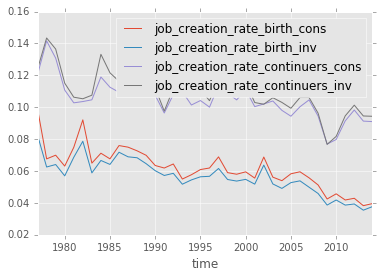

```python
cons_invs_sectors[['job_creation_rate_birth_cons','job_creation_rate_birth_inv',
                   'job_creation_rate_continuers_cons','job_creation_rate_continuers_inv']].plot(kind='line')
```

```python
def labor_share(group):
    group = group.dropna(subset=['labor compensation','Consumption Share','Investment Share',
                                 'Taxes on production and imports less subsidies','Value added'])
    labor_comp_con = (group['labor compensation']*group['Consumption Share']).sum()
    labor_comp_inv = (group['labor compensation']*group['Investment Share']).sum()
    taxes_con = (group['Taxes on production and imports less subsidies']*group['Consumption Share']).sum()
    taxes_inv = (group['Taxes on production and imports less subsidies']*group['Investment Share']).sum()
    value_added_con = (group['Value added']*group['Consumption Share']).sum()
    value_added_inv = (group['Value added']*group['Investment Share']).sum()

    labor_share_con = labor_comp_con/(value_added_con-taxes_con)
    labor_share_inv = labor_comp_inv/(value_added_inv-taxes_inv)

    return pd.Series({'labor_share_cons':labor_share_con,
                     'labor_share_inv':labor_share_inv})
```

```python
labor_shares = bds_io_income_emp[bds_io_income_emp.time>=1987].groupby(['time']).apply(labor_share)
print(labor_shares.mean())
```

```
labor_share_cons    0.656426
labor_share_inv     0.623538
dtype: float64
```

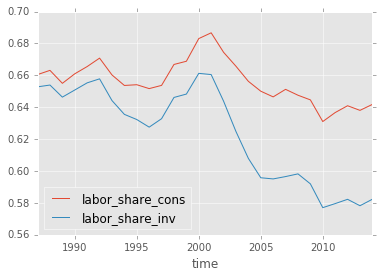

```python
labor_shares.plot(kind='line')
```

Calculate growth rate of relative price of investment goods, $g_{P_I}$

```python
start = datetime.datetime(init_year, 1, 1)
end = datetime.datetime(last_year, 12, 31)
emp_series = ['PIRIC']
p_x = web.DataReader( emp_series, 'fred', start, end)
```

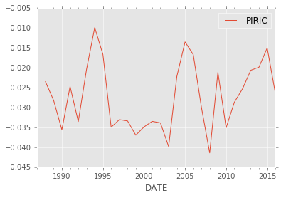

```python
p_x.resample('A').mean().pct_change().plot(kind='line')
```

```python
g_pi = p_x.resample('A').mean().pct_change().mean().values[0]
md('Growth rate of realtive price of invesment good is {0:.3f}.'.format(g_pi))
```

Growth rate of realtive price of invesment good is -0.027.

```python
lines = ['| Target | Moment/Parameter | Value| \n',
         '|--------|:-------:|----------| \n',
         '| Output growth | $g_y$ | {0:.3f} | \n'.format(g_y),
         '| Interest rate | $R$ | {0:.2f}| \n'.format(R),
         r'| Discount factor | $\rho$ | {0:.3f} | '.format(rho), '\n',
         '|Entry rate (consumption) | $z_c$ | {0:.3f} | \n'.format(cons_invs_sectors.mean()['job_creation_rate_birth_cons']),
        '|Entry rate (investment) | $z_x$ | {0:.3f} | \n'.format(cons_invs_sectors.mean()['job_creation_rate_birth_inv']),
         '|Expansion rate (consumption) | $b_c$ | {0:.3f} | \n'.format(cons_invs_sectors.mean()['job_creation_rate_continuers_cons']),
        '|Expansion rate (investment) | $b_x$ | {0:.3f} | \n'.format(cons_invs_sectors.mean()['job_creation_rate_continuers_inv']),
        '| Relative price of investment goods | $g_p$ | {0:.3f} | \n'.format(g_pi),
        r'| Labor share (consumption) | ~$(1-\theta)/ \lambda_c$ | {0:.2f} |'.format(labor_shares.mean()['labor_share_cons']),'\n',
        r'| Labor share (consumption) | ~$(1-\alpha)/ \lambda_x$ | {0:.2f} |'.format(labor_shares.mean()['labor_share_inv']),'\n']
md(''.join(lines))
```

| Target | Moment/Parameter | Value |
| --- | --- | --- |
| Output growth | $g_y$ | 0.016 |
| Interest rate | $R$ | 0.04 |
| Discount factor | $\rho$ | 0.024 |
| Entry rate (consumption) | $z_c$ | 0.062 |
| Entry rate (investment) | $z_x$ | 0.056 |
| Expansion rate (consumption) | $b_c$ | 0.105 |
| Expansion rate (investment) | $b_x$ | 0.109 |
| Relative price of investment goods | $g_p$ | -0.027 |
| Labor share (consumption) | ~$(1-\theta)/ \lambda_c$ | 0.66 |
| Labor share (consumption) | ~$(1-\alpha)/ \lambda_x$ | 0.62 |

Calibration with a single sector

```python
bds_io_income_emp_single = bds_io_income_emp
bds_io_income_emp_single['Consumption Share'] = 1
bds_io_income_emp_single['Investment Share'] = 1
single_sector = bds_io_income_emp_single.groupby('time').apply(calc_cons_invs_sector)
single_sector.mean()
```

```
emp_cons                                1.802683e+08
emp_inv                                 1.802683e+08
job_creation_rate_birth_cons            6.073282e-02
job_creation_rate_birth_inv             6.073282e-02
job_creation_rate_continuers_cons       1.057745e-01
job_creation_rate_continuers_inv        1.057745e-01
job_destruction_rate_continuers_cons    9.205806e-02
job_destruction_rate_continuers_inv     9.205806e-02
job_destruction_rate_death_cons         4.990369e-02
job_destruction_rate_death_inv          4.990369e-02
dtype: float64
```

```python
labor_shares_single = bds_io_income_emp_single[bds_io_income_emp_single.time>=1987].groupby(['time']).apply(labor_share)
print(labor_shares_single.mean())
```

```
labor_share_cons    0.647567
labor_share_inv     0.647567
dtype: float64
```

```python
lines = ['| Target | Moment/Parameter | Value| \n',
         '|--------|:-------:|----------| \n',
         '| Output growth | $g_y$ | {0:.3f} | \n'.format(g_y),
         '| Interest rate | $R$ | {0:.2f}| \n'.format(R),
         r'| Discount factor | $\rho$ | {0:.3f} | '.format(rho), '\n',
         '|Entry rate | $z_c$ | {0:.3f} | \n'.format(single_sector.mean()['job_creation_rate_birth_cons']),
         '|Expansion rate | $b_c$ | {0:.3f} | \n'.format(single_sector.mean()['job_creation_rate_continuers_cons']),
        r'| Labor share | ~$(1-\theta)/ \lambda$ | {0:.2f} |'.format(labor_shares_single.mean()['labor_share_cons']),'\n']
md(''.join(lines))
```

| Target | Moment/Parameter | Value |
| --- | --- | --- |
| Output growth | $g_y$ | 0.016 |
| Interest rate | $R$ | 0.04 |
| Discount factor | $\rho$ | 0.024 |
| Entry rate | $z_c$ | 0.061 |
| Expansion rate | $b_c$ | 0.106 |
| Labor share | ~$(1-\theta)/ \lambda$ | 0.65 |

### Labor Productivity

```python
import requests
import json
import prettytable
headers = {'Content-type': 'application/json'}
data = json.dumps({"seriesid": ['CUUR0000SA0','SUUR0000SA0'],"startyear":"2011", "endyear":"2014",
                  "registrationkey":"377229fe62d943d0a0603d77ca037cd3"})
p = requests.post('https://api.bls.gov/publicAPI/v2/timeseries/data/', data=data, headers=headers)
json_data = json.loads(p.text)
data_seq = pd.DataFrame()
for series in json_data['Results']['series']:
    data_ = pd.DataFrame(series['data'])
    data_ = data_.drop(['footnotes','period'],axis=1)
    data_['series'] = series['seriesID']
    data_seq = data_seq.append(data_)
```

```python
lpc = pd.read_excel('./data/labor_productivity.xlsx',sheet_name='Data',header=1)
```

```python
industries_digits = []
for i in range(6,1,-1):
    select = lpc['Industry Digit'] == str(i)+'-Digit'
    industs = lpc[select]['Industry'].str.slice(0,i).unique()
    industries_digits.append(industs)
```

```python
m = []
for i in range(4):
    indust = industries_digits[i]
    z = []
    for ind in indust:
        keep = True
        for j in range(2,7-i):
            if ind[:j] in industries_digits[-j+1]:
                keep = False
        if keep:
            z.append(ind)
    m.append(z)
```

```python
value_vars = lpc.columns.values[5:]
id_vars = lpc.columns.values[:5]

lpc= pd.melt(lpc, id_vars=id_vars, value_vars=value_vars,var_name='Year', value_name='Value')
lpc['Value']=pd.to_numeric(lpc['Value'],errors='coerce')
```

```python
industry_super = dict(zip(lpc['Industry Sector'].unique(),lpc['Industry Sector'].str.slice(0,2).unique()))
industry_super['31,32,33 - Manufacturing'] = '31G'
industry_super['44,45 - Retail Trade'] = '44RT'
industry_super['48,49 - Transportation and Warehousing'] = '48TW'
industry_super['52 - Finance and Insurance'] = 'FIRE'
industry_super['53 - Real Estate and Rental and Leasing'] = 'FIRE'
industry_super['54 - Professional, Scientific, and Technical Services'] = 'PROF'
industry_super['56 - Administrative and Support and Waste Management and Remediation Services'] = 'PROF'
industry_super['62 - Health Care and Social Assistance'] = '6'
industry_super['71 - Arts, Entertainment, and Recreation'] = '7'
industry_super['72 - Accommodation and Food Services'] = '7'
```

```python
lpc['industry super'] = lpc['Industry Sector'].map(industry_super)
```

```python
def labor_prod_growth(group):
    select_prod = ((group['Measure'] == 'Labor productivity') & (group['Units'] == '1-Yr Rate'))
    select_emp = ((group['Measure'] == 'Number of employees') & (group['Units'] == 'thousands'))
    prod = np.array(group[select_prod]['Value'].values)
    emp = np.array(group[select_emp]['Value'].values)
    emp_sum = np.sum(emp)
    return pd.Series({'prod_growth':np.sum(prod*emp/emp_sum),'total_emp':emp_sum})
```

```python
industry = [lpc[lpc['Industry Digit']== str(i)+'-Digit']['Industry Sector'].unique() for i in range(2,7)]
```

```python
sector = [industry[i-2] if i == 2 else np.setdiff1d(industry[i-2],industry[i-3]) for i in range(2,7) ]
```

```python
select_i = lpc['Industry Sector'].map(lambda x: x in sector[0])
select = (select_i & (lpc['Industry Digit'] == '2-Digit') &
          (lpc.Measure == 'Labor productivity') & (lpc.Units == '1-Yr Rate'))
lpc_growth = lpc[select][['Industry Sector','Year','Value']]
lpc_growth['prod_growth'] = lpc_growth['Value']
lpc_growth['total_emp'] = 1
lpc_growth = lpc_growth.drop('Value',axis=1)
for i in range(3,7):
    select_i = lpc['Industry Sector'].map(lambda x: x in sector[i-2])
    select = (select_i & (lpc['Industry Digit'] == str(i)+'-Digit'))
    lpc_productivity_growth = lpc[select].groupby(['Industry Sector', 'Year']).apply(labor_prod_growth)
    lpc_productivity_growth = lpc_productivity_growth.reset_index()
    lpc_productivity_growth = lpc_productivity_growth.rename(columns={0:'Value'})
    lpc_growth = lpc_growth.append(lpc_productivity_growth)
```

```python
lpc_growth['industry super'] = lpc_growth['Industry Sector'].map(industry_super)
```

```python
def ave_prod_growth(group):
    emp = group['total_emp'].values
    prod = group['prod_growth'].values
    total_emp = np.sum(emp)
    ave_prod = np.sum(emp*prod/total_emp)
    return ave_prod
```

```python
lpc_average_growth = lpc_growth.groupby(['industry super','Year']).apply(ave_prod_growth).reset_index().groupby('industry super')[0].mean()/100
```

```python
lpc_average_growth-lpc_average_growth.loc['31G']
```

```
industry super
21     -0.006984
22     -0.000317
31G     0.000000
42      0.006583
44RT    0.007707
48TW   -0.015178
51      0.016266
6      -0.001945
7      -0.024956
81     -0.004155
FIRE    0.010732
PROF    0.012070
Name: 0, dtype: float64
```